# Statistical inference with the GSS data

## Setup

### Load packages

```r
library(ggplot2)
library(dplyr)
library(statsr)
```

### Load data

```r
load("gss.Rdata")
```

## Part 1: Data

GSS data was obtained by face-to-fce interview (vast majority), computer-assisted personal interview (CAPI) (began 2002), or telephone. Source of bias: due to long interview, there are number of people who do not participate in the interviews or do not fully answer the questions.

Scope of inference-generalization: the data consists of 57061 people from American society with random sampling. Hence, this study has generalization.

Scope of inference-causation: this is an observational study and has no causation. Only correlation could be established using statistical inference.

## Part 2: Research question

Study the difference between hours of watching TV per days for man and woman. This is important question concerning time spent in front of TV for man and woman.

Two parameters needed:

sex: Respondent’s sex

tvhours: hours of watching TV per days

## Part 3: Exploratory data analysis

EDA and summary statistics.

```r
load("gss.Rdata")
gss %>%
group_by(sex,tvhours) %>%
filter(!is.na(sex),!is.na(tvhours),tvhours != "") %>%
summarise(count = n())
```

```
## # A tibble: 47 x 3
## # Groups:   sex [?]
##    sex   tvhours count
##    <fct>   <int> <int>
##  1 Male        0   697
##  2 Male        1  3124
##  3 Male        2  4174
##  4 Male        3  2865
##  5 Male        4  1825
##  6 Male        5   839
##  7 Male        6   555
##  8 Male        7   120
##  9 Male        8   230
## 10 Male        9    18
## # ... with 37 more rows
```

EDA by genders and TV hours.

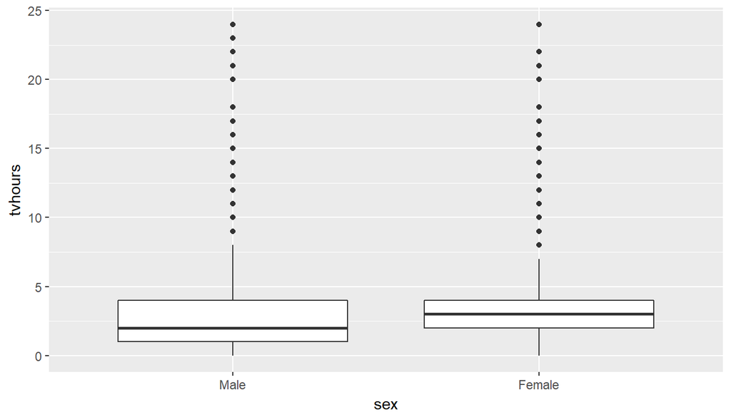

```r
ggplot(data = gss, mapping = aes(x = sex, y = tvhours)) + geom_boxplot()# +   facet_grid(sex ~.)
```

This is a box plot showing the gender difference in number of TV hours.

## Part 4: Inference

```r
gss <- gss %>%
       filter(!is.na(tvhours))
inference(y = tvhours, x = sex, data = gss, statistic = "mean", type = "ci", conf_level = 0.95, method = "theoretical")
```

```
## Response variable: numerical, Explanatory variable: categorical (2 levels)
## n_Male = 14754, y_bar_Male = 2.8221, s_Male = 2.236
## n_Female = 19101, y_bar_Female = 3.0855, s_Female = 2.434
## 95% CI (Male - Female): (-0.3133 , -0.2135)
```

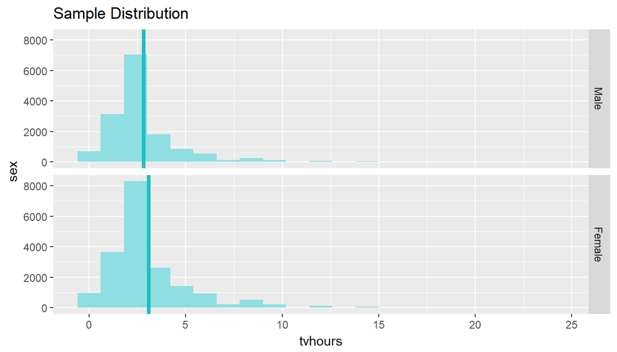

Inference was performer using mean statistics since we compare the mean of TV hours for male and female, using confident interval test.